# Reinforcement Learning

2025

## Reinforcement Learning

- Hebbian learning is sometimes called **two-factor** learning.
- The first factor is the **presynaptic** activity and the second factor is the **postsynaptic** activity.
- **Reinforcement learning** adds a third factor:
  - Did something **unexpectedly** good or bad happen?
  - If good, increase active weights.
  - If bad, decrease active weights.
  - This is the **reinforcement signal**.

## Edward Thorndike

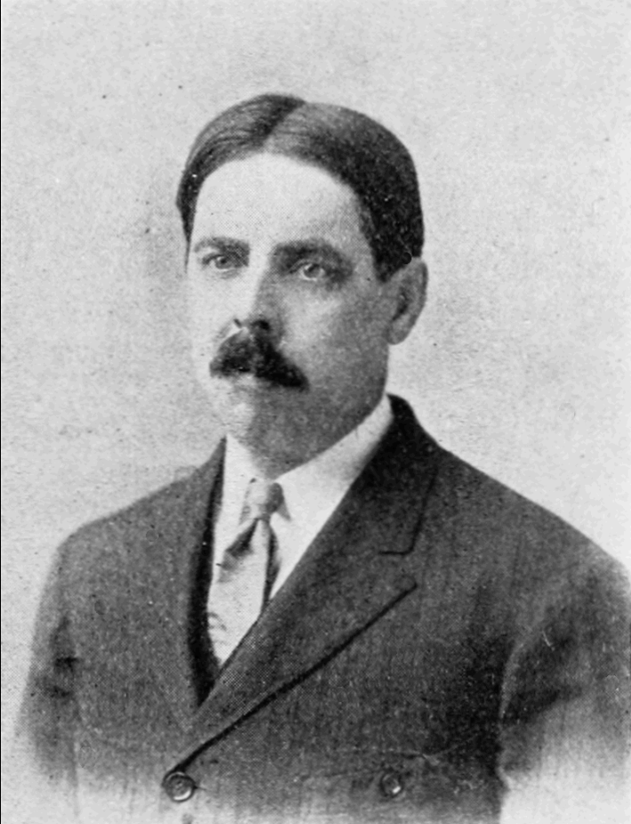

- **Edward Thorndike** (1874–1949) was a psychologist who studied animal learning.

## Thorndike’s Puzzle Box

[figure not shown]

- **Law of Effect** (1905):
  - Behaviours followed by satisfying outcomes become more likely.
  - Behaviours followed by discomfort become less likely.

## Pavlovian Conditioning

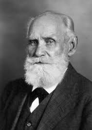

- **Ivan Pavlov** (1849–1936) was a Russian physiologist who studied the physiology of digestion.

## Pavlov’s Dogs

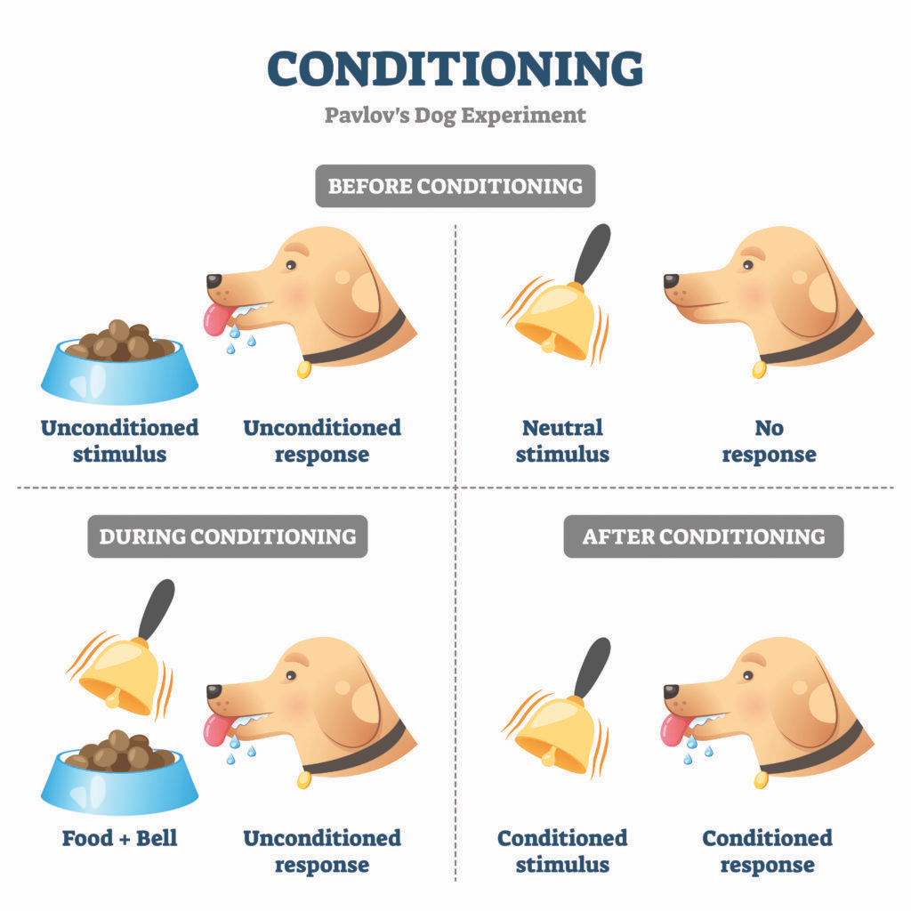

- Pavlov’s dogs learned to salivate at the sound of a bell that was previously paired with food.

## B.F. Skinner and Operant Conditioning

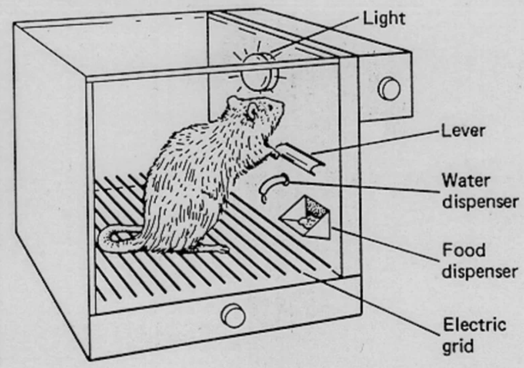

- **B.F. Skinner** (1904–1990) formalised the concept of **reinforcement** as a core driver of learning.
- **Positive reinforcement**: increases behavior by presenting a reward.
- **Negative reinforcement**: increases behavior by removing an aversive stimulus.

## Classical vs. Operant Conditioning

- Skinner distinguished between **Classical / Pavlovian conditioning** and **Operant / Instrumental conditioning**
- **Classical conditioning:** Reinforcement is **uncontrollable** and occurs **independently** of the subject’s behavior.
- **Operant conditioning:** Reinforcement is **controllable** and occurs **dependently** on the subject’s behavior.

## Mathematical Foundations of Associative Learning

- Psychologists like **Bush & Mosteller (1955)** and **Rescorla & Wagner (1972)** developed formal models of **stimulus-response (S-R) associative learning**.
- These models describe learning as a gradual change in associative strength driven by **prediction error**.

\[ \Delta V = \alpha (R - V) \]

- \(V\) is the current associative strength and also serves as a prediction of the outcome.
- \(R\) is the actual outcome (e.g., presence or absence of reward).
- \(\alpha\) is a learning rate parameter,

## Reinforcement Learning in Computer Science

- In the **1980s and 1990s**, **Richard Sutton** and **Andrew Barto** began formalising artificially intelligent agents that learn from reward.
- Their models were deeply influenced by animal learning research and aimed to **formalize learning mechanisms observed in nature**.
- Reinforcement learning is still an important part modern AI, including for training systems like large language models (LLMs), robotics, and game-playing agents.

## Reinforcement Learning in the Brain

\[ \Delta V = \alpha (R - V) \]

- \(\alpha\) is a learning rate parameter.
- \(R\) is the obtained reward.
- \(V\) is the predicted reward.
- \((R - V)\) is the **reward prediction error**.
- Easy to show that this learning rule causes \(V\) to converge to the expected value of \(R\).

## Dopamine Neurons Signal Reward Prediction Error

- If something better than expected occurs, the prediction error is **positive** and dopamine neurons increase firing.
- If something worse than expected occurs, the prediction error is **negative** and dopamine neurons decrease firing.
- The magnitude of the prediction error is encoded by the **rate of firing** of dopamine neurons.

## Dopamine Neurons Signal Reward Prediction Error

[output not shown]

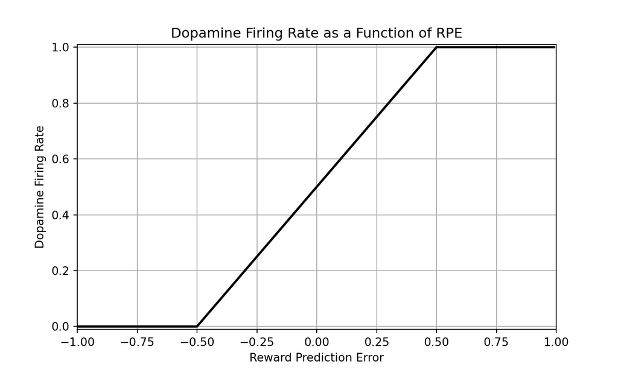

## Synaptic Plasiticity at Cortico-Striatal Synapses

- The synaptic weights between the **cortex** and the **striatum** follow a three-factor learning rule.
- Factor 1: presynaptic activity (cortical neurons).
- Factor 2: postsynaptic activity (striatal projection neurons).
- Factor 3: reinforcement signal provided by dopamine released into the striatum from the midbrain.

## Synaptic Plasiticity at Cortico-Striatal Synapses on the Direct Pathway

- The confluence of strong pre- and postsynaptic activity leads to activation of NMDA receptors, causing calcium influx and initiating intracellular signaling cascades, including CaMKII phosphorylation.
- Dopamine release above baseline, typically following a positive reward prediction error, activates D1 receptors on direct pathway medium spiny neurons in the striatum, leading to phosphorylation of DARPP-32.
- When both CaMKII and DARPP-32 are phosphorylated, this promotes synaptic potentiation, particularly via enhanced AMPA receptor trafficking and gene transcription.
- When CaMKII is phosphorylated but DARPP-32 is not – as may occur during low or negative dopamine conditions (e.g., negative prediction error) – synaptic weakening (depression) is more likely.

## Synaptic Plasiticity at Cortico-Striatal Synapses on the Indirect Pathway

- The confluence of strong pre- and postsynaptic activity leads to activation of NMDA receptors, calcium influx, and phosphorylation of CaMKII, similar to the direct pathway.
- Dopamine dips below baseline, typically following a negative reward prediction error, lead to reduced activation of D2 receptors on indirect pathway medium spiny neurons (MSNs), thereby disinhibiting intracellular signaling cascades that favor synaptic weakening.
- When CaMKII is phosphorylated and D2 receptor activation is low, intracellular pathways (e.g., increased cAMP/PKA activity) facilitate long-term depression (LTD).
- Under baseline or elevated dopamine, activation of D2 receptors suppresses these LTD pathways, making synaptic weakening less likely.

## Comparing Synaptic Plasticity in Direct vs. Indirect Pathways

[output not shown]

## Reinforcement Learning Weight Update Rule

\[ \begin{align} w_{ij}(n+1) &= w_{ij}(n) \pm \alpha A_j(n) A_i(n) \delta(n) \\ \delta(n) &= r_{\text{obtained}}(n) - r_{\text{predicted}}(n) \\ r_{\text{obtained}}(n) &= \text{to be determined by the experiment} \\ r_{\text{predicted}}(n) &= \text{must be estimated from experience} \\ \end{align} \]

- The \(\pm\) sign is meant to reflect the opposite processes along the direct and indirect pathways.
- Here, we took the simplest Hebbian learning rule as a base, but we could have taken any of the other Hebbian learning rules as a base instead.

## Estimating Predicted Reward

- Given the learning rule above, the weight \(w_{ij}\) itself is in essence an estimate of the predicted reward.
- However it is more common for reinforcement learning in the brain to treat the system driving actions (i.e., the weight \(w_{ij}\)) as separate from the system evaluating outcomes and generating predictions.
- This type of separation is frequently referred to as the **actor-critic** model of reinforcement learning.
- For this reason we will estimate the predicted reward separately from the weight update rule.

## Estimating Predicted Reward

- We won’t need a sophisticated model to estimate the predicted reward. The following will suffice:

```python
r_obtained = np.zeros(n_trials) # obtained reward
r_predicted = np.zeros(n_trials) # predicted reward

alpha_pr = 0.1 # learning rate for predicted reward

for i in range(0, n_trials-1):
    # code to determine r_obtained would go here

    # update the predicted reward
    r_predicted[i+1] = r_predicted[i] + alpha_pr * (r_obtained[i] - r_predicted[i])
```

## Reinforcement Learning on the Direct Pathway

```python
# Do all the necessary initialization etc...

# Begin the simulation
for trl in range(N-1): # iterate over trials
    for i in range(1, n): # iterate over time steps
        # update neurons...

    # determine network action...
    # determine obtained reward...
    # determine predicted reward...
    # update weights with bio Hebbian learning rule modified for RL...
```

## Reinforcement Learning on the Direct Pathway

```python
    # Determine response probability. In the case of modelling a
    # rodent in a simple lever pressing task, it's common to
    # model the probability of pressing the lever as a
    # smooth function of the associative strength (i.e., the
    # relevant synaptic weight).
    resp_prob = 1.0 / (1.0 + np.exp(-w[trl] * 10 + 5))

    # determine network action
    if np.random.rand() < resp_prob:
        response = 1
    else:
        response = 0
```

## Reinforcement Learning on the Direct Pathway

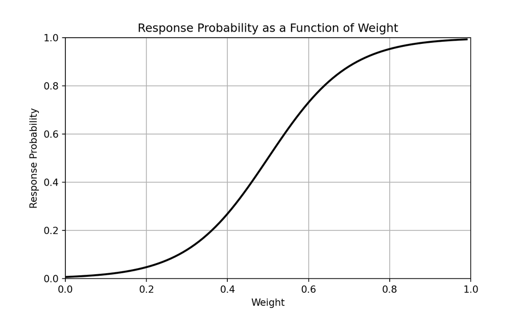

## Reinforcement Learning on the Direct Pathway

```python
    # determine obtained reward
    if response == 1:
        r_obtained = 1.0
    else:
        r_obtained = 0.0

    # determine reward prediction error
    delta = r_obtained - r_predicted

    # determine predicted reward
    r_predicted = r_predicted + alpha_pr * (r_obtained - r_predicted)
```

## Reinforcement Learning on the Direct Pathway

```python
    # update weights with bio Hebbian learning rule modified for RL
    alpha = 1e-9; beta = 1e-9; lamb = 1e-20; theta = 1e8;

    pre = g_A[trl, :].sum()
    post = g_B[trl, :].sum()

    post_ltp_1 = np.heaviside(post - theta, 0)
    post_ltd_1 = np.heaviside(theta - post, 0)

    post_ltp_2 = 1.0 - np.exp(-lamb * (post - theta))
    post_ltd_2 = np.exp(-lamb * (theta - post))
```

## Reinforcement Learning on the Direct Pathway

```python
    delta_w = 0.0
    if delta[trl] > 0:
        # LTP caused by strong post-synaptic activity and positive reward prediction error
        delta_w += alpha * pre * post_ltp_1 * post_ltp_2 * (1 - w[trl]) * delta[trl]
    else:
        # LTD caused by strong post-synaptic activity and negative reward prediction error
        delta_w -= alpha * pre * post_ltp_1 * post_ltp_2 * w[trl] * np.abs(delta[trl])

    # LTD also caused by weak post-synaptic activity
    delta_w -= beta * pre * post_ltd_1 * post_ltd_2 * w[trl]
```